# Writeup Course Project Practical Machine Learning

Lukas Meyer

6/22/2017

## General Information

Using devices such as Jawbone Up, Nike FuelBand, and Fitbit it is now possible to collect a large amount of data about personal activity relatively inexpensively. These type of devices are part of the quantified self movement – a group of enthusiasts who take measurements about themselves regularly to improve their health, to find patterns in their behavior, or because they are tech geeks. One thing that people regularly do is quantify how much of a particular activity they do, but they rarely quantify how well they do it. In this project, your goal will be to use data from accelerometers on the belt, forearm, arm, and dumbell of 6 participants. They were asked to perform barbell lifts correctly and incorrectly in 5 different ways. More information is available from the website here: http://groupware.les.inf.puc-rio.br/har (see the section on the Weight Lifting Exercise Dataset).

The training data for this project are available here: https://d396qusza40orc.cloudfront.net/predmachlearn/pml-training.csv

The test data are available here: https://d396qusza40orc.cloudfront.net/predmachlearn/pml-testing.csv

## Objective

The goal of this analysis is to predict the manner in which they did the exercise. This is the “classe” variable in the training set. The result will be a prediction model to predict 20 different test cases.

## Loading libraries and the data

Lets load our data sets (training and testing). We are going to set additional na strings in order to remove unnecessary division by zero or empty values that are present in the data set.

```r
library(caret)
setwd('/Users/lmeyer/Documents/Data Science Projects/Coursera Course - Data Scienctists Toolbox/Course 8 - Practical Machine Learning')
train <- read.csv('./pml-training.csv', na.strings=c('#DIV/0', '', 'NA') ,stringsAsFactors = F)
validation <- read.csv('./pml-testing.csv', na.strings=c('#DIV/0', '', 'NA') ,stringsAsFactors = F)
```

## Data Exploration

```r
str(train,list.len=10)
```

```
## 'data.frame':    19622 obs. of  160 variables:
##  $ X                       : int  1 2 3 4 5 6 7 8 9 10 ...
##  $ user_name               : chr  "carlitos" "carlitos" "carlitos" "carlitos" ...
##  $ raw_timestamp_part_1    : int  1323084231 1323084231 1323084231 1323084232 1323084232 1323084232 1323084232 1323084232 1323084232 1323084232 ...
##  $ raw_timestamp_part_2    : int  788290 808298 820366 120339 196328 304277 368296 440390 484323 484434 ...
##  $ cvtd_timestamp          : chr  "05/12/2011 11:23" "05/12/2011 11:23" "05/12/2011 11:23" "05/12/2011 11:23" ...
##  $ new_window              : chr  "no" "no" "no" "no" ...
##  $ num_window              : int  11 11 11 12 12 12 12 12 12 12 ...
##  $ roll_belt               : num  1.41 1.41 1.42 1.48 1.48 1.45 1.42 1.42 1.43 1.45 ...
##  $ pitch_belt              : num  8.07 8.07 8.07 8.05 8.07 8.06 8.09 8.13 8.16 8.17 ...
##  $ yaw_belt                : num  -94.4 -94.4 -94.4 -94.4 -94.4 -94.4 -94.4 -94.4 -94.4 -94.4 ...
##   [list output truncated]
```

```r
dim(train)
```

```
## [1] 19622   160
```

The first features appear to be only relevant for informational purposes. Also there exist a lot of features with 100% empty or NA values that are not needed. The data set contains a lot of features (160) therefore it would make a lot of sense to simplify our feature selection to decrease our model complexity.

## Data Manipulation

```r
set.seed(12345)

# Remove first seven columns
train <- train[, 7:ncol(train)]
validation <- validation[, 7:ncol(validation)]

# Keep only columns with all records. There are a lot of columns that contain only NA values thus cannot be used.
not_na  <- apply(!is.na(train), 2, sum) > 19621
train <- train[, not_na]
validation  <- validation[, not_na]

# Remove features with near zero variance because they would not have a strong impact and would unnecessarily over-complicate our model.
nzv_train <- nearZeroVar(train,saveMetrics=FALSE)
if(length(nzv_train) > 0) {
  train <- train[, -nzv_cols]
}
```

After preparing and cleaning up our data sets we’re going to split our training data into two separate data sets in order to select our model and validate its performance. We’ll use a 60/40 split

```r
inTrain = createDataPartition(train$classe, p = 0.6, list = F)
training = train[ inTrain[,1],]
testing = train[-inTrain[,1],]
```

## Model Definition

We’re going to use a tree based random forest model as well as a gradient boosting model and compare their performances. Furthermore we’ll use 2-fold cross validation for model training because our training data is rather large but it is faster than 10-fold cv. We can still increase if our model accuracy is low.

```r
# 2-fold cross validation
ctl <- trainControl(method = "cv", number = 2, allowParallel = TRUE)

# Model 1 using rf
fit_rf <- train(classe ~ .,
    data = training,
    method = "rf",
    trControl=ctl,
    importance = TRUE)

# Model 2 using gbm
fit_gbm <- train(classe ~ .,
    data = training,
    method = "gbm",
    trControl=ctl,
    verbose=FALSE)
```

```r
rf_imp <- varImp(fit_rf, scale=FALSE)
```

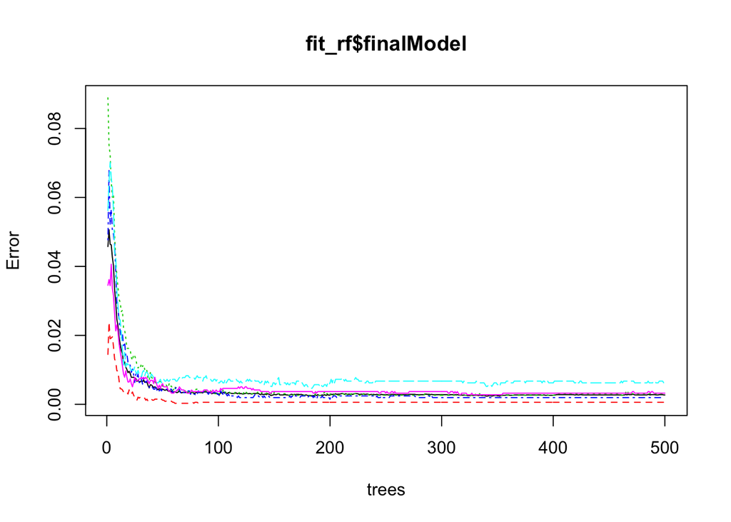

```r
plot(fit_rf$finalModel)
```

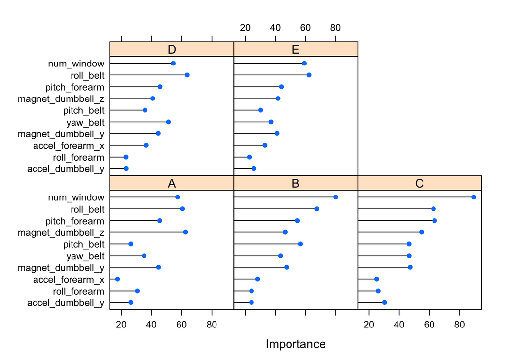

```r
plot(rf_imp, top=10)
```

## Model Selection

After training our two models we’ll be comparing each models performance against our testing set. We’ll create a confusion matrix to show the accuracy.

```r
## See how our RF model performs
pred_rf <- predict(fit_rf,testing[,!(names(testing) %in% "classe")])
acc_rf <- round(confusionMatrix(testing$classe,pred_rf)$overall[1],5)
oos_rf <- round(1-confusionMatrix(testing$classe,pred_rf)$overall[1],5)

## See how our GBM model performs
pred_gbm <- predict(fit_gbm,testing[,!(names(testing) %in% "classe")])
acc_gbm <- round(confusionMatrix(testing$classe,pred_gbm)$overall[1],5)
oos_gbm <- round(1-confusionMatrix(testing$classe,pred_gbm)$overall[1],5)


print(paste0("Accuracy Random Forest: ", acc_rf))
```

```
## [1] "Accuracy Random Forest: 0.99707"
```

```r
print(paste0("Out of Sample Error RF: ", oos_rf))
```

```
## [1] "Out of Sample Error RF: 0.00293"
```

```r
print(paste0("Accuracy Gradient Boosting: ", acc_gbm))
```

```
## [1] "Accuracy Gradient Boosting: 0.98534"
```

```r
print(paste0("Out of Sample Error GBM: ", oos_gbm))
```

```
## [1] "Out of Sample Error GBM: 0.01466"
```

We can observe that both models have a very high accuracy hence they are equally good for predicting our validation classes. Random Forest has a slighthly higher accuracy 0.99707 and a smaller out of sample error of 0.00293 hence we’ll be using RF for our final prediction.

## Final Prediction for Submission

Based on our model we’ll predict the classe of our test set with the result shown below.

```r
validation$final_prediction <- predict(fit_rf, validation)
print(validation$final_prediction)
```

```
##  [1] B A B A A E D B A A B C B A E E A B B B
## Levels: A B C D E
```

## Conclusion

Using a random forest model we get a very high accuracy and an out of sample error of 0.00293. This gives us a high confidence in predicting the training classes for our test set.